# Limpieza y Manipulación de Datos

León Berdichevsky Acosta

21 de agosto de 2018

En estas notas abordaremos los temas de limpieza y manipulación de datos utilizando el paquete `tidyverse` de R. Trataremos los siguientes puntos:

- Los principios de datos limpios.
- Aspectos básicos de manipulación de datos.
- Reestructuración de bases de datos.
- Estrategia divide-aplica-combina.

Es sabido que limpieza y preparación de datos ocupan gran parte del tiempo del análisis de datos ([Dasu y Johnson, 2003](http://onlinelibrary.wiley.com/book/10.1002/0471448354) y [NYT’s ‘Janitor Work’ Is Key Hurdle to Insights](https://www.nytimes.com/2014/08/18/technology/for-big-data-scientists-hurdle-to-insights-is-janitor-work.html?mcubz=0)); es por ello que vale la pena dedicar un tiempo a aprender técnicas que faciliten estas tareas, y entender con qué estructura de los datos es más conveniente trabajar.

### Datos Limpios

Una vez que importamos datos a R es conveniente limpiarlos, esto implica almacenarlos de una manera consisistente que nos permita enfocarnos en responder preguntas con los datos en lugar de estar luchando con los datos. Entonces, **datos limpios** son datos que facilitan las tareas del análisis de datos:

- **Manipulación:** Manipulación de variables como agregar, filtrar, reordenar, transformar.
- **Visualización:** Resúmenes de datos usando gráficas, análisis exploratorio, o presentación de resultados.
- **Modelación:** Ajustar modelos es sencillo si los datos están en la forma correcta.

Los principios de **datos limpios** ([Tidy Data de Hadley Wickham](http://vita.had.co.nz/papers/tidy-data.pdf)) proveen una manera estándar de organizar la información.

Para enunciarlos, es necesario introducir el concepto de Unidad Observacional. Una **Unidad Observacional** (o Unidad de Observación) es la entidad mayor, primaria o representativa de lo que va a ser objeto específico de estudio en una medición y se refiere al qué o quién es objeto de interés en una investigación. A este objeto de estudio le medimos ciertas características. Una unidad observacional tiene las siguientes propiedades:

- Una unidad observacional en una tabla puede estar definida por una o más variables.
- El resto de las variables de la tabla corresponden a las características de la unidad observacional.

Los principios de datos limpios son:

1. Cada variable forma una columna.
2. Cada tipo de unidad observacional forma una tabla.
3. Cada valor de la unidad observacional forma un renglón.

Vale la pena notar que los principios de datos limpios se pueden ver como teoría de algebra relacional para estadísticos; estos principios equivalen a la tercera forma normal de Codd con enfoque en una sola tabla de datos en lugar de muchas conectadas en bases de datos relacionales.

La mayor parte de las bases de datos en estadística tienen forma de tabla rectangular, es decir, están constituidas por datos representados de manera tabular. En el presente curso consideraremos únicamente datos con esta estructura.

**Ejemplo:** Considere la siguiente tabla que representa a 3 individuos expuestos a uno o dos tipos de tratamientos (denotados A y B) y en la que se muestra el resultado del tratamiento correspondiente.

|  | tratamientoA | tratamientoB |
| --- | --- | --- |
| Juan Aguirre | - | 2 |
| Ana Bernal | 16 | 11 |
| José López | 3 | 1 |

¿Cuántas variables tiene la tabla? La respuesta más sencilla es 3 variables: nombre, tipo de tratamiento y resultado del tratamiento.

La tabla anterior también se puede reestructurar de la siguiente manera:

|  | Juan Aguirre | Ana Bernal | José López |
| --- | --- | --- | --- |
| tratamientoA | - | 16 | 3 |
| tratamientoB | 2 | 11 | 1 |

¿Cumplen las tablas anteriores los principios de datos limpios? La respuesta depende del número de variables y de la definición de unidad observacional.

En este caso, independientemente de la definición de unidad observacional, es claro que la respuesta es NO, ya que ambas tablas violan el principio número 1.

Reestructurando la tabla, obtenemos una nueva tabla que cumple con el principio número 1 de datos limpios:

| nombre | tipo de tratamiento | resultado del tratamiento |
| --- | --- | --- |
| Juan Aguirre | a | - |
| Ana Bernal | a | 16 |
| José López | a | 3 |
| Juan Aguirre | b | 2 |
| Ana Bernal | b | 11 |
| José López | b | 1 |

¿Esta tabla cumple con los principios de datos limpios? Por construcción cumple con el principio número 1. Sin embargo, los principios 2 y 3 dependen de la definición de unidad observacional. En este caso, si la unidad observacional está definida por las variables nombre y tipo de tratamiento, es claro que la tabla cumple con los principios de datos limpios. Sin embargo, una definición diferente de unidad observacional podría implicar que la tabla no cumple con dichos principios.

**Ejercicio:** Define una unidad observacional para el ejemplo anterior tal que la última tabla no cumpla con el principio de datos limpios. Reestructura la tabla en una nueva tabla que sí cumpla con los principios de datos limpios.

### Aspectos básicos de manipulación de datos

Para abordar el tema de Limpieza de Datos, es necesario familiarizarse con aspectos básicos de manipulación de datos. Ilustraremos estos aspectos utilizando funciones que se encuentran en el paquete `tidyverse`. Más adelante regresaremos de lleno al tema de Manipulación de Datos cuando veamos la Estategia divide-aplica-combina.

```r
library(tidyverse)
```

Un *tibble* es un Data Frame en R adaptado al paquete `tidyverse` mediante el paquete `tibble`. Creamos un tibble utilizando la función con el mismo nombre:

```r
df_ej <- tibble(genero = c("mujer", "hombre", "mujer", "mujer", "hombre"),
                estatura = c(1.65, 1.80, 1.70, 1.60, 1.67))
df_ej
```

```
#> # A tibble: 5 x 2
#>   genero estatura
#>   <chr>     <dbl>
#> 1 mujer      1.65
#> 2 hombre     1.8
#> 3 mujer      1.7
#> 4 mujer      1.6
#> 5 hombre     1.67
```

```r
str(df_ej)
```

```
#> Classes 'tbl_df', 'tbl' and 'data.frame':    5 obs. of  2 variables:
#>  $ genero  : chr  "mujer" "hombre" "mujer" "mujer" ...
#>  $ estatura: num  1.65 1.8 1.7 1.6 1.67
```

En específico, estudiaremos las funciones del paquete `dplyr` que es parte del paquete `tidyverse` para manipular *datos limpios*: filtrar, seleccionar, arreglar, mutar y realizar sumarizados. El objeto de entrada de todas estas funciones es un `tibble` y el objeto de salida es también un `tibble`.

#### Filtrar

Obtiene un subconjunto de las filas de acuerdo a un criterio:

```r
filter(df_ej, genero == "mujer")
```

```
#> # A tibble: 3 x 2
#>   genero estatura
#>   <chr>     <dbl>
#> 1 mujer      1.65
#> 2 mujer      1.7
#> 3 mujer      1.6
```

```r
filter(df_ej, estatura > 1.65 & estatura < 1.75)
```

```
#> # A tibble: 2 x 2
#>   genero estatura
#>   <chr>     <dbl>
#> 1 mujer      1.7
#> 2 hombre     1.67
```

#### Seleccionar

Selecciona columnas de acuerdo al nombre:

```r
df_ej
```

```
#> # A tibble: 5 x 2
#>   genero estatura
#>   <chr>     <dbl>
#> 1 mujer      1.65
#> 2 hombre     1.8
#> 3 mujer      1.7
#> 4 mujer      1.6
#> 5 hombre     1.67
```

```r
select(df_ej, genero)
```

```
#> # A tibble: 5 x 1
#>   genero
#>   <chr>
#> 1 mujer
#> 2 hombre
#> 3 mujer
#> 4 mujer
#> 5 hombre
```

```r
select(df_ej, -genero) #Elige todas las columnas excepto la llamada "genero"
```

```
#> # A tibble: 5 x 1
#>   estatura
#>      <dbl>
#> 1     1.65
#> 2     1.8
#> 3     1.7
#> 4     1.6
#> 5     1.67
```

```r
select(df_ej, starts_with("g")) #Nombre empieza con la letra "g"
```

```
#> # A tibble: 5 x 1
#>   genero
#>   <chr>
#> 1 mujer
#> 2 hombre
#> 3 mujer
#> 4 mujer
#> 5 hombre
```

```r
select(df_ej, contains("g")) #Nombre contiene la letra "g"
```

```
#> # A tibble: 5 x 1
#>   genero
#>   <chr>
#> 1 mujer
#> 2 hombre
#> 3 mujer
#> 4 mujer
#> 5 hombre
```

#### Arreglar

Reordena las filas:

```r
arrange(df_ej, genero) #Orden alfabético
```

```
#> # A tibble: 5 x 2
#>   genero estatura
#>   <chr>     <dbl>
#> 1 hombre     1.8
#> 2 hombre     1.67
#> 3 mujer      1.65
#> 4 mujer      1.7
#> 5 mujer      1.6
```

```r
arrange(df_ej, desc(estatura)) #Orden numérico descendente
```

```
#> # A tibble: 5 x 2
#>   genero estatura
#>   <chr>     <dbl>
#> 1 hombre     1.8
#> 2 mujer      1.7
#> 3 hombre     1.67
#> 4 mujer      1.65
#> 5 mujer      1.6
```

#### Mutar

Crea y agrega nuevas variables:

```r
mutate(df_ej, estatura_cm = estatura * 100)
```

```
#> # A tibble: 5 x 3
#>   genero estatura estatura_cm
#>   <chr>     <dbl>       <dbl>
#> 1 mujer      1.65         165
#> 2 hombre     1.8          180
#> 3 mujer      1.7          170
#> 4 mujer      1.6          160
#> 5 hombre     1.67         167
```

```r
mutate(df_ej, estatura_cm = estatura * 100, estatura_in = estatura_cm * 0.3937)
```

```
#> # A tibble: 5 x 4
#>   genero estatura estatura_cm estatura_in
#>   <chr>     <dbl>       <dbl>       <dbl>
#> 1 mujer      1.65         165        65.0
#> 2 hombre     1.8          180        70.9
#> 3 mujer      1.7          170        66.9
#> 4 mujer      1.6          160        63.0
#> 5 hombre     1.67         167        65.7
```

#### Sumarizados

Crea nuevas bases de datos con resúmenes o agregaciones de los datos originales:

```r
summarise(df_ej, promedio = mean(estatura))
```

```
#> # A tibble: 1 x 1
#>   promedio
#>      <dbl>
#> 1     1.68
```

Podemos hacer resúmenes por grupo. Para ello primero creamos una base de datos con información de *agrupación* con respecto a la variable género (nota que la tabla no cambió, únicamente le agregamos el atributo `grupo`):

```r
by_genero <- group_by(df_ej, genero)
by_genero
```

```
#> # A tibble: 5 x 2
#> # Groups:   genero [2]
#>   genero estatura
#>   <chr>     <dbl>
#> 1 mujer      1.65
#> 2 hombre     1.8
#> 3 mujer      1.7
#> 4 mujer      1.6
#> 5 hombre     1.67
```

Después operamos sobre cada grupo, creando un resumen a nivel grupo:

```r
summarise(by_genero, promedio = mean(estatura))
```

```
#> # A tibble: 2 x 2
#>   genero promedio
#>   <chr>     <dbl>
#> 1 hombre     1.74
#> 2 mujer      1.65
```

#### Estableciendo el Directorio de Trabajo (*Working Directory* (WD))

Cuando cargamos archivo, R siempre los llama desde el Directorio de Trabajo. Para consultar cuál es el Directorio de Trabajo actual de nuestra sesión en R utilizamos el comando:

```r
getwd() #Directorio de Trabajo actual
```

```
#> [1] "D:/Otono 2018/Estadistica Computacional/03. Manipulacion y Limpieza de Datos"
```

Si deseamos cambiar el Directorio de Trabajo, especificamos el nuevo folder mediante el comando:

```r
#setwd("C:/Users/lberdicha/Documents/ITAM/Cursos 2017/Otono 2017/Estadistica Computacional/Modulo 2")   #Change WD
getwd()
```

```
#> [1] "D:/Otono 2018/Estadistica Computacional/03. Manipulacion y Limpieza de Datos"
```

Para obtener una lista de los archivos que se encuentran en el Directorio de Trabajo:

```r
dir() #Lista de archivos en el WD
```

```
#> [1] "03-Limpieza-y-Manipulacion-de-Datos.html"
#> [2] "03-Limpieza-y-Manipulacion-de-Datos.knit.md"
#> [3] "03-Limpieza-y-Manipulacion-de-Datos.Rmd"
#> [4] "03-Limpieza-y-Manipulacion-de-Datos.utf8.md"
#> [5] "03. Ejercicios.R"
#> [6] "03._Limpieza_y_Manipulacion_de_Datos.html"
#> [7] "data"
#> [8] "imagenes"
```

### Limpieza y Reestructuración de Bases de Datos

Los principios de datos limpios parecen obvios pero la mayor parte de las bases de datos no los cumplen debido a que:

1. La mayor parte de la gente no está familiarizada con los principios y es difícil derivarlos por uno mismo.
2. Los datos suelen estar organizados para facilitar otros aspectos que no son el análisis de datos; por ejemplo, la captura de los datos.

Algunos de los problemas más comunes en las bases de datos que no están *limpias* son:

1. Los encabezados de las columnas son valores de otra variable.
2. Más de una variable por columna.
3. Las variables están organizadas tanto en filas como en columnas.
4. Más de un tipo de unidad observacional en una tabla.
5. Una misma unidad observacional está almacenada en múltiples tablas.

La mayor parte de estos problemas se pueden arreglar con pocas herramientas; a continuación veremos como *limpiar* datos usando 2 funciones del paquete `tidyr`:

Repasaremos los problemas más comunes que se encuentran en conjuntos de datos sucios y mostraremos como se puede manipular la tabla de datos (usando las funciones *gather* y *spread*) con el fin de estructurarla para que cumpla los principios de datos limpios.

#### 1. Los encabezados de las columanas son valores de otra variable.

Usaremos ejemplos para entender los conceptos más facilmente.

##### Ejemplo 1:

La primer base de datos está basada en una encuesta de [Pew Research](http://www.pewforum.org/2009/01/30/income-distribution-within-us-religious-groups/) que investiga la relación entre ingreso y afiliación religiosa.

Cargamos la base de datos de una URL:

```r
library(tidyverse)
pew <- read_delim("http://stat405.had.co.nz/data/pew.txt", "\t",
  escape_double = FALSE, trim_ws = TRUE)
head(pew)
```

```
#> # A tibble: 6 x 11
#>   religion       `<$10k` `$10-20k` `$20-30k` `$30-40k` `$40-50k` `$50-75k`
#>   <chr>            <int>     <int>     <int>     <int>     <int>     <int>
#> 1 Agnostic            27        34        60        81        76       137
#> 2 Atheist             12        27        37        52        35        70
#> 3 Buddhist            27        21        30        34        33        58
#> 4 Catholic           418       617       732       670       638      1116
#> 5 Don’t know/re~      15        14        15        11        10        35
#> 6 Evangelical P~     575       869      1064       982       881      1486
#> # ... with 4 more variables: `$75-100k` <int>, `$100-150k` <int>,
#> #   `>150k` <int>, `Don't know/refused` <int>
```

¿Cuáles son las variables en estos datos? Esta base de datos tiene 3 variables: religión, ingreso y frecuencia.

Para *limpiarla* es necesario apilar las columnas (*alargar* los datos). Notemos que al alargar los datos desapareceran las columnas que se agrupan y dan lugar a dos nuveas columnas: la correspondiente a clave y la correspondiente a valor. Para alargar una base de datos usamos la función `gather` que recibe los argumentos:

- data: base de datos que vamos a reestructurar.
- key: nombre de la nueva variable que contiene como valores los nombres de las columnas que vamos a apilar.
- value: nombre de la variable que almacenará los valores que corresponden a cada *key*.
- …: lo último que especificamos son las columnas que vamos a apilar, la notación para seleccionarlas es la misma que usamos con `select()`.

```r
pew_tidy <- gather(data = pew, income, frequency, -religion) #En este caso indicamos la columna que NO vamos a apilar
head(pew_tidy)
```

```
#> # A tibble: 6 x 3
#>   religion           income frequency
#>   <chr>              <chr>      <int>
#> 1 Agnostic           <$10k         27
#> 2 Atheist            <$10k         12
#> 3 Buddhist           <$10k         27
#> 4 Catholic           <$10k        418
#> 5 Don’t know/refused <$10k         15
#> 6 Evangelical Prot   <$10k        575
```

```r
str(pew_tidy)
```

```
#> Classes 'tbl_df', 'tbl' and 'data.frame':    180 obs. of  3 variables:
#>  $ religion : chr  "Agnostic" "Atheist" "Buddhist" "Catholic" ...
#>  $ income   : chr  "<$10k" "<$10k" "<$10k" "<$10k" ...
#>  $ frequency: int  27 12 27 418 15 575 1 228 20 19 ...
```

Observemos que en la tabla *ancha* teníamos bajo la columna *<$10k*, en el renglón correspondiente a *Agnostic* un valor de 27, y podemos ver que este valor en la tabla *larga* se almacena bajo la columna frecuencia y corresponde a los valores *Agnostic* de religión, y *<$10k* de income. También es importante ver que en este ejemplo especificamos las columnas a apilar identificando la que NO vamos a alargar con un signo negativo: es decir apila todas las columnas menos religión.

La nueva estructura de la base de datos nos permite, por ejemplo, hacer fácilmente una gráfica donde podemos comparar las diferencias en las frecuencias.

Nota: En esta sección no explicaremos las funciones para graficar pues estas se cubren en las notas de Visualización en R. En esta parte nos concentramos en cómo limpiar datos y ejemplificar lo sencillo que es trabajar con datos limpios, esto es, una vez que los datos fueron reestructurados e tal forma que cumplan con el principio de datos limpios es fácil construir gráficas y resúmenes estadísticos.

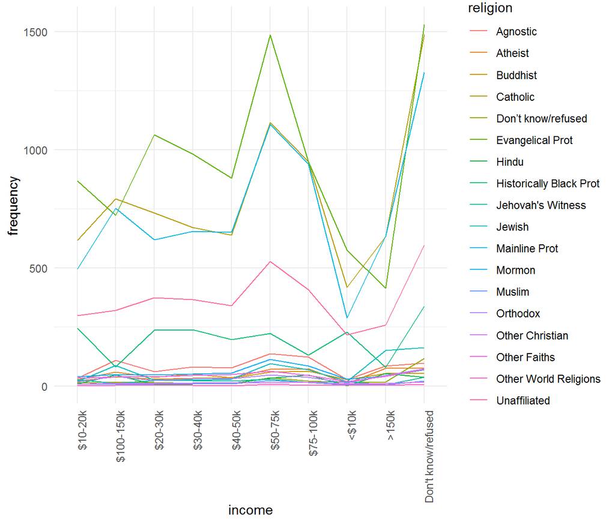

```r
ggplot(pew_tidy, aes(x = income, y = frequency, color = religion, group = religion)) +
  geom_line() +
  theme(axis.text.x = element_text(angle = 90, hjust = 1))
```

Podemos hacer gráficas más interesantes si creamos nuevas variables:

```r
by_religion <- group_by(pew_tidy, religion)
pew_tidy_2 <- pew_tidy %>%
  filter(income != "Don't know/refused") %>%
  group_by(religion) %>%
  mutate(percent = frequency / sum(frequency)) %>%
  filter(sum(frequency) > 1000)

head(pew_tidy_2)
```

```
#> # A tibble: 6 x 4
#> # Groups:   religion [5]
#>   religion                income  frequency percent
#>   <chr>                   <chr>       <int>   <dbl>
#> 1 Catholic                <$10k         418  0.0637
#> 2 Evangelical Prot        <$10k         575  0.0724
#> 3 Historically Black Prot <$10k         228  0.138
#> 4 Mainline Prot           <$10k         289  0.0471
#> 5 Unaffiliated            <$10k         217  0.0698
#> 6 Catholic                $10-20k       617  0.0940
```

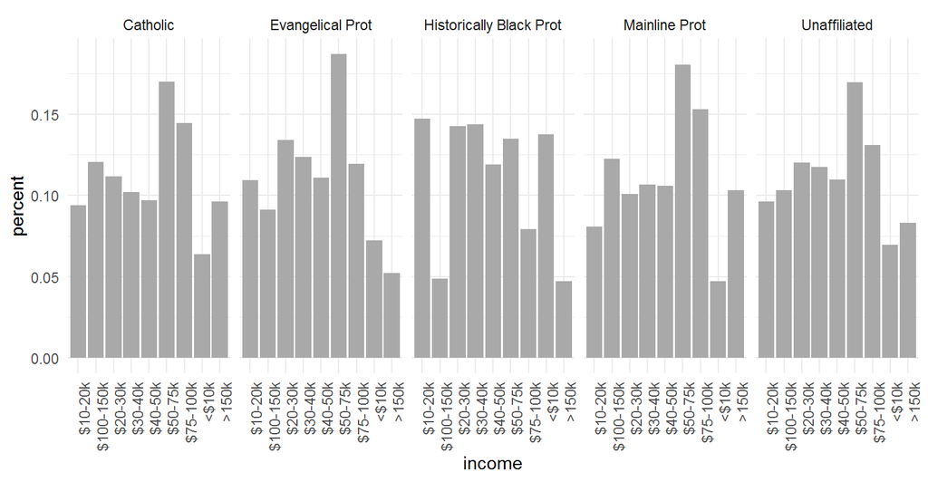

```r
ggplot(pew_tidy_2, aes(x = income, y = percent, group = religion)) +
  facet_wrap(~ religion, nrow = 1) +
  geom_bar(stat = "identity", fill = "darkgray") +
  theme(axis.text.x = element_text(angle = 90, hjust = 1))
```

##### Ejemplo 2:

Veamos los datos de la tabla `Billboard`, aquí se registra la fecha en la que una canción entra por primera vez al top 100 de Billboard.

Cargamos la base de datos de un documento en formato .csv (comma separated values) de nuestro equipo:

```r
billboard <- read_csv("data/billboard.csv")
head(billboard)
```

```
#> # A tibble: 6 x 81
#>    year artist   track    time  date.entered   wk1   wk2   wk3   wk4   wk5
#>   <int> <chr>    <chr>    <tim> <date>       <int> <int> <int> <int> <int>
#> 1  2000 2 Pac    Baby Do~ 04:22 2000-02-26      87    82    72    77    87
#> 2  2000 2Ge+her  The Har~ 03:15 2000-09-02      91    87    92    NA    NA
#> 3  2000 3 Doors~ Krypton~ 03:53 2000-04-08      81    70    68    67    66
#> 4  2000 3 Doors~ Loser    04:24 2000-10-21      76    76    72    69    67
#> 5  2000 504 Boyz Wobble ~ 03:35 2000-04-15      57    34    25    17    17
#> 6  2000 98^0     Give Me~ 03:24 2000-08-19      51    39    34    26    26
#> # ... with 71 more variables: wk6 <int>, wk7 <int>, wk8 <int>, wk9 <int>,
#> #   wk10 <int>, wk11 <int>, wk12 <int>, wk13 <int>, wk14 <int>,
#> #   wk15 <int>, wk16 <int>, wk17 <int>, wk18 <int>, wk19 <int>,
#> #   wk20 <int>, wk21 <int>, wk22 <int>, wk23 <int>, wk24 <int>,
#> #   wk25 <int>, wk26 <int>, wk27 <int>, wk28 <int>, wk29 <int>,
#> #   wk30 <int>, wk31 <int>, wk32 <int>, wk33 <int>, wk34 <int>,
#> #   wk35 <int>, wk36 <int>, wk37 <int>, wk38 <int>, wk39 <int>,
#> #   wk40 <int>, wk41 <int>, wk42 <int>, wk43 <int>, wk44 <int>,
#> #   wk45 <int>, wk46 <int>, wk47 <int>, wk48 <int>, wk49 <int>,
#> #   wk50 <int>, wk51 <int>, wk52 <int>, wk53 <int>, wk54 <int>,
#> #   wk55 <int>, wk56 <int>, wk57 <int>, wk58 <int>, wk59 <int>,
#> #   wk60 <int>, wk61 <int>, wk62 <int>, wk63 <int>, wk64 <int>,
#> #   wk65 <int>, wk66 <chr>, wk67 <chr>, wk68 <chr>, wk69 <chr>,
#> #   wk70 <chr>, wk71 <chr>, wk72 <chr>, wk73 <chr>, wk74 <chr>,
#> #   wk75 <chr>, wk76 <chr>
```

```r
#str(billboard)
```

Para tener datos *limpios* apilamos las semanas de manera que sea una sola columna (nuevamente *alargamos* los datos):

```r
billboard_long <- gather(billboard, week, rank, wk1:wk76, na.rm = TRUE) #Eliminamos valores faltantes de la variable rank
head(billboard_long)
```

```
#> # A tibble: 6 x 7
#>    year artist       track                  time  date.entered week  rank
#>   <int> <chr>        <chr>                  <tim> <date>       <chr> <chr>
#> 1  2000 2 Pac        Baby Don't Cry (Keep.~ 04:22 2000-02-26   wk1   87
#> 2  2000 2Ge+her      The Hardest Part Of .~ 03:15 2000-09-02   wk1   91
#> 3  2000 3 Doors Down Kryptonite             03:53 2000-04-08   wk1   81
#> 4  2000 3 Doors Down Loser                  04:24 2000-10-21   wk1   76
#> 5  2000 504 Boyz     Wobble Wobble          03:35 2000-04-15   wk1   57
#> 6  2000 98^0         Give Me Just One Nig.~ 03:24 2000-08-19   wk1   51
```

```r
str(billboard_long)
```

```
#> Classes 'tbl_df', 'tbl' and 'data.frame':    5307 obs. of  7 variables:
#>  $ year        : int  2000 2000 2000 2000 2000 2000 2000 2000 2000 2000 ...
#>  $ artist      : chr  "2 Pac" "2Ge+her" "3 Doors Down" "3 Doors Down" ...
#>  $ track       : chr  "Baby Don't Cry (Keep..." "The Hardest Part Of ..." "Kryptonite" "Loser" ...
#>  $ time        : 'hms' num  04:22:00 03:15:00 03:53:00 04:24:00 ...
#>   ..- attr(*, "units")= chr "secs"
#>  $ date.entered: Date, format: "2000-02-26" "2000-09-02" ...
#>  $ week        : chr  "wk1" "wk1" "wk1" "wk1" ...
#>  $ rank        : chr  "87" "91" "81" "76" ...
```

Notemos que en esta ocasión especificamos las columnas que vamos a apilar indicando el nombre de la primera de ellas seguido de `:` y por último el nombre de la última variable a apilar. Por otra parte, la instrucción `na.rm = TRUE` se utiliza para eliminar los renglones con valores faltantes en la columna de value (rank), esto es, eliminamos aquellas observaciones que tenían NA en la columnas wk*num* de la tabla *ancha*. Ahora realizamos una limpieza adicional creando mejores variables de fecha.

```r
billboard_tidy <- billboard_long %>%
  mutate(
    week = parse_number(week),
    date = date.entered + 7 * (week - 1),
    rank = as.numeric(rank)
    ) %>%
    select(-date.entered)
head(billboard_tidy)
```

```
#> # A tibble: 6 x 7
#>    year artist       track                   time    week  rank date
#>   <int> <chr>        <chr>                   <time> <dbl> <dbl> <date>
#> 1  2000 2 Pac        Baby Don't Cry (Keep... 04:22      1    87 2000-02-26
#> 2  2000 2Ge+her      The Hardest Part Of ... 03:15      1    91 2000-09-02
#> 3  2000 3 Doors Down Kryptonite              03:53      1    81 2000-04-08
#> 4  2000 3 Doors Down Loser                   04:24      1    76 2000-10-21
#> 5  2000 504 Boyz     Wobble Wobble           03:35      1    57 2000-04-15
#> 6  2000 98^0         Give Me Just One Nig... 03:24      1    51 2000-08-19
```

Nuevamente, podemos hacer gráficas fácilmente:

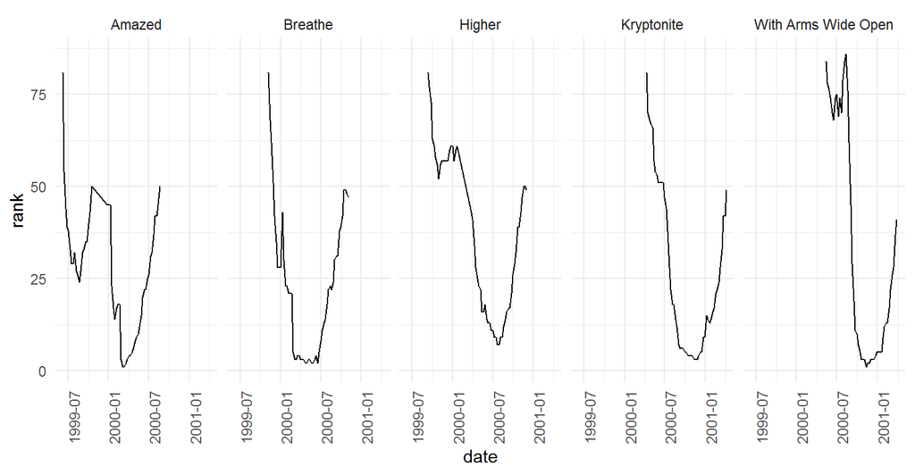

```r
tracks <- filter(billboard_tidy, track %in%
    c("Higher", "Amazed", "Kryptonite", "Breathe", "With Arms Wide Open"))

ggplot(tracks, aes(x = date, y = rank)) +
  geom_line() +
  facet_wrap(~track, nrow = 1) +
  theme(axis.text.x = element_text(angle = 90, hjust = 1))
```

#### 2. Una columna asociada a más de una variable

La siguiente base de datos proviene de la Organización Mundial de la Salud (OMS) y contiene el número de casos confirmados de tuberculosis por país y año, la información esta por grupo demográfico de acuerdo a sexo (m, f), y edad (0-4, 5-14, etc). Los datos están disponibles en http://www.who.int/tb/country/data/download/en/.

```r
tb <- read.csv("data/tb.csv") #Notar que utilizamos la función read.csv en lugar de read_csv
head(tb)
```

```
#>   iso2 year new_sp_m04 new_sp_m514 new_sp_m014 new_sp_m1524 new_sp_m2534
#> 1   AD 1989         NA          NA          NA           NA           NA
#> 2   AD 1990         NA          NA          NA           NA           NA
#> 3   AD 1991         NA          NA          NA           NA           NA
#> 4   AD 1992         NA          NA          NA           NA           NA
#> 5   AD 1993         NA          NA          NA           NA           NA
#> 6   AD 1994         NA          NA          NA           NA           NA
#>   new_sp_m3544 new_sp_m4554 new_sp_m5564 new_sp_m65 new_sp_mu new_sp_f04
#> 1           NA           NA           NA         NA        NA         NA
#> 2           NA           NA           NA         NA        NA         NA
#> 3           NA           NA           NA         NA        NA         NA
#> 4           NA           NA           NA         NA        NA         NA
#> 5           NA           NA           NA         NA        NA         NA
#> 6           NA           NA           NA         NA        NA         NA
#>   new_sp_f514 new_sp_f014 new_sp_f1524 new_sp_f2534 new_sp_f3544
#> 1          NA          NA           NA           NA           NA
#> 2          NA          NA           NA           NA           NA
#> 3          NA          NA           NA           NA           NA
#> 4          NA          NA           NA           NA           NA
#> 5          NA          NA           NA           NA           NA
#> 6          NA          NA           NA           NA           NA
#>   new_sp_f4554 new_sp_f5564 new_sp_f65 new_sp_fu
#> 1           NA           NA         NA        NA
#> 2           NA           NA         NA        NA
#> 3           NA           NA         NA        NA
#> 4           NA           NA         NA        NA
#> 5           NA           NA         NA        NA
#> 6           NA           NA         NA        NA
```

```r
str(tb)
```

```
#> 'data.frame':    5769 obs. of  22 variables:
#>  $ iso2        : Factor w/ 212 levels "AD","AE","AF",..: 1 1 1 1 1 1 1 1 1 1 ...
#>  $ year        : int  1989 1990 1991 1992 1993 1994 1996 1997 1998 1999 ...
#>  $ new_sp_m04  : int  NA NA NA NA NA NA NA NA NA NA ...
#>  $ new_sp_m514 : int  NA NA NA NA NA NA NA NA NA NA ...
#>  $ new_sp_m014 : int  NA NA NA NA NA NA 0 0 0 0 ...
#>  $ new_sp_m1524: int  NA NA NA NA NA NA 0 0 0 0 ...
#>  $ new_sp_m2534: int  NA NA NA NA NA NA 0 1 0 0 ...
#>  $ new_sp_m3544: int  NA NA NA NA NA NA 4 2 1 1 ...
#>  $ new_sp_m4554: int  NA NA NA NA NA NA 1 2 0 1 ...
#>  $ new_sp_m5564: int  NA NA NA NA NA NA 0 1 0 0 ...
#>  $ new_sp_m65  : int  NA NA NA NA NA NA 0 6 0 0 ...
#>  $ new_sp_mu   : int  NA NA NA NA NA NA NA NA NA NA ...
#>  $ new_sp_f04  : int  NA NA NA NA NA NA NA NA NA NA ...
#>  $ new_sp_f514 : int  NA NA NA NA NA NA NA NA NA NA ...
#>  $ new_sp_f014 : int  NA NA NA NA NA NA 0 0 NA 0 ...
#>  $ new_sp_f1524: int  NA NA NA NA NA NA 1 1 NA 0 ...
#>  $ new_sp_f2534: int  NA NA NA NA NA NA 1 2 NA 0 ...
#>  $ new_sp_f3544: int  NA NA NA NA NA NA 0 3 NA 1 ...
#>  $ new_sp_f4554: int  NA NA NA NA NA NA 0 0 NA 0 ...
#>  $ new_sp_f5564: int  NA NA NA NA NA NA 1 0 NA 0 ...
#>  $ new_sp_f65  : int  NA NA NA NA NA NA 0 1 NA 0 ...
#>  $ new_sp_fu   : int  NA NA NA NA NA NA NA NA NA NA ...
```

**Ejercicio:** De manera similar a los ejemplos anteriores, utiliza la función `gather` para apilar las columnas correspondientes a género-edad.

Notemos que las variables género y edad se encuentran almacenadas en una sola variable: demo. Para reestructurar la base de datos en una base de datos limpia debemos separar en dos columnas la variable demo, una para almacenar la variable género y otra para la variable edad. Para ello utilizaremos la función `separate()`, esta recibe como parámetros:

- el nombre de la base de datos,
- el nombre de la variable que deseamos separar en más de una,
- la posición de donde deseamos “cortar” (hay más opciones para especificar como separar, ver `?separate`). El default es separar valores en todos los lugares que encuentre un caracter que no es alfanumérico (espacio, guión,…).

```r
tb_tidy <- separate(tb_long, demo, c("sex", "age"), 8)
head(tb_tidy)
```

```
#>    iso2 year      sex age n
#> 16   AD 2005 new_sp_m  04 0
#> 17   AD 2006 new_sp_m  04 0
#> 19   AD 2008 new_sp_m  04 0
#> 43   AE 2006 new_sp_m  04 0
#> 44   AE 2007 new_sp_m  04 0
#> 45   AE 2008 new_sp_m  04 0
```

```r
table(tb_tidy$sex) #Frecuencias de las clases de la variable sex
```

```
#>
#> new_sp_f new_sp_m
#>    17830    17920
```

Creamos una mejor codificación de la variable género:

```r
tb_tidy <- mutate(tb_tidy, sex = substr(sex, 8, 8))
head(tb_tidy)
```

```
#>   iso2 year sex age n
#> 1   AD 2005   m  04 0
#> 2   AD 2006   m  04 0
#> 3   AD 2008   m  04 0
#> 4   AE 2006   m  04 0
#> 5   AE 2007   m  04 0
#> 6   AE 2008   m  04 0
```

```r
table(tb_tidy$sex)
```

```
#>
#>     f     m
#> 17830 17920
```

#### 3. Variables almacenadas en filas y columnas

El problema más difícil es cuando las variables se encuentran almacenadas tanto en filas como encolumnas.

Consideremos una base de datos de clima en Cuernavaca:

```r
clima <- read_delim("data/clima.txt", "\t", escape_double = FALSE, trim_ws = TRUE)
head(clima)
```

```
#> # A tibble: 6 x 35
#>   id          year month element    d1    d2    d3    d4    d5    d6    d7
#>   <chr>      <int> <int> <chr>   <int> <int> <int> <int> <int> <int> <int>
#> 1 MX0000170~  2010     1 TMAX       NA    NA    NA    NA    NA    NA    NA
#> 2 MX0000170~  2010     1 TMIN       NA    NA    NA    NA    NA    NA    NA
#> 3 MX0000170~  2010     2 TMAX       NA   273   241    NA    NA    NA    NA
#> 4 MX0000170~  2010     2 TMIN       NA   144   144    NA    NA    NA    NA
#> 5 MX0000170~  2010     3 TMAX       NA    NA    NA    NA   321    NA    NA
#> 6 MX0000170~  2010     3 TMIN       NA    NA    NA    NA   142    NA    NA
#> # ... with 24 more variables: d8 <int>, d9 <chr>, d10 <int>, d11 <int>,
#> #   d12 <chr>, d13 <int>, d14 <int>, d15 <int>, d16 <int>, d17 <int>,
#> #   d18 <chr>, d19 <chr>, d20 <chr>, d21 <chr>, d22 <chr>, d23 <int>,
#> #   d24 <chr>, d25 <int>, d26 <int>, d27 <int>, d28 <int>, d29 <int>,
#> #   d30 <int>, d31 <int>
```

¿Cuáles son las variables en estos datos? Estos datos tienen variables en columnas individuales (id, año, mes), en múltiples columnas (día, d1-d31) y en filas (tmin, tmax).

Comencemos por apilar las columnas:

```r
clima_long <- gather(clima, day, value, d1:d31, na.rm = TRUE)
head(clima_long)
```

```
#> # A tibble: 6 x 6
#>   id           year month element day   value
#>   <chr>       <int> <int> <chr>   <chr> <chr>
#> 1 MX000017004  2010    12 TMAX    d1    299
#> 2 MX000017004  2010    12 TMIN    d1    138
#> 3 MX000017004  2010     2 TMAX    d2    273
#> 4 MX000017004  2010     2 TMIN    d2    144
#> 5 MX000017004  2010    11 TMAX    d2    313
#> 6 MX000017004  2010    11 TMIN    d2    163
```

Podemos crear algunas variables adicionales:

```r
clima_vars <- clima_long %>%
  mutate(day = parse_number(day),
    value = as.numeric(value) / 10) %>%
  select(id, year, month, day, element, value) %>%
  arrange(id, year, month, day)
head(clima_vars)
```

```
#> # A tibble: 6 x 6
#>   id           year month   day element value
#>   <chr>       <int> <int> <dbl> <chr>   <dbl>
#> 1 MX000017004  2010     1    30 TMAX     27.8
#> 2 MX000017004  2010     1    30 TMIN     14.5
#> 3 MX000017004  2010     2     2 TMAX     27.3
#> 4 MX000017004  2010     2     2 TMIN     14.4
#> 5 MX000017004  2010     2     3 TMAX     24.1
#> 6 MX000017004  2010     2     3 TMIN     14.4
```

Finalmente, la columna *element* no es una variable, sino que almacena el nombre de dos variables, la operación que debemos aplicar es `spread`, la cual es el inverso de la función `gather`:

```r
clima_tidy <- spread(clima_vars, element, value)
head(clima_tidy)
```

```
#> # A tibble: 6 x 6
#>   id           year month   day  TMAX  TMIN
#>   <chr>       <int> <int> <dbl> <dbl> <dbl>
#> 1 MX000017004  2010     1    30  27.8  14.5
#> 2 MX000017004  2010     2     2  27.3  14.4
#> 3 MX000017004  2010     2     3  24.1  14.4
#> 4 MX000017004  2010     2    11  29.7  13.4
#> 5 MX000017004  2010     2    23  29.9  10.7
#> 6 MX000017004  2010     3     5  32.1  14.2
```

Ahora es inmediato realizar gráficas y ajustar un modelo. Consideremos ajustar una Regresión Linea Simple:

```r
# Ajustamos un modelo lineal donde la variable respuesta es temperatura máxima, y la variable explicativa es el mes
clima_lm <- lm(TMAX ~ factor(month), data = clima_tidy)
summary(clima_lm)
```

```
#>
#> Call:
#> lm(formula = TMAX ~ factor(month), data = clima_tidy)
#>
#> Residuals:
#>    Min     1Q Median     3Q    Max
#>  -3.65  -0.92  -0.02   1.05   3.18
#>
#> Coefficients:
#>                 Estimate Std. Error t value Pr(>|t|)
#> (Intercept)      27.8000     1.8610  14.938 5.34e-13 ***
#> factor(month)2   -0.0500     2.0807  -0.024  0.98104
#> factor(month)3    4.7667     2.1489   2.218  0.03717 *
#> factor(month)4    8.5000     2.6319   3.230  0.00385 **
#> factor(month)5    5.4000     2.6319   2.052  0.05228 .
#> factor(month)6    1.2500     2.2793   0.548  0.58892
#> factor(month)7    1.4500     2.2793   0.636  0.53123
#> factor(month)8    0.4714     1.9895   0.237  0.81488
#> factor(month)10   1.1000     2.0386   0.540  0.59491
#> factor(month)11   0.3200     2.0386   0.157  0.87670
#> factor(month)12   1.0500     2.2793   0.461  0.64955
#> ---
#> Signif. codes:  0 '***' 0.001 '**' 0.01 '*' 0.05 '.' 0.1 ' ' 1
#>
#> Residual standard error: 1.861 on 22 degrees of freedom
#> Multiple R-squared:  0.6182, Adjusted R-squared:  0.4447
#> F-statistic: 3.563 on 10 and 22 DF,  p-value: 0.006196
```

#### 4. Mas de un tipo de unidad observacional en una misma (Separación o Unión horizontal)

En ocasiones las bases de datos involucran valores en diferentes niveles, en diferentes tipos de unidad observacional. En la limpieza de datos, cada unidad observacional debe estar almacenada en su propia tabla (esto está ligado a normalización de una base de datos); es importante para evitar inconsistencias en los datos.

Consideremos de nuevo la base de datos `billboard`:

```r
head(billboard_tidy)
```

```
#> # A tibble: 6 x 7
#>    year artist       track                   time    week  rank date
#>   <int> <chr>        <chr>                   <time> <dbl> <dbl> <date>
#> 1  2000 2 Pac        Baby Don't Cry (Keep... 04:22      1    87 2000-02-26
#> 2  2000 2Ge+her      The Hardest Part Of ... 03:15      1    91 2000-09-02
#> 3  2000 3 Doors Down Kryptonite              03:53      1    81 2000-04-08
#> 4  2000 3 Doors Down Loser                   04:24      1    76 2000-10-21
#> 5  2000 504 Boyz     Wobble Wobble           03:35      1    57 2000-04-15
#> 6  2000 98^0         Give Me Just One Nig... 03:24      1    51 2000-08-19
```

¿Cuáles son las unidades observacionales de los datos de billboard? # Notar que cada canción está asociada a un artista y una duración. Sin embargo, tenemos un ranking de la canción por semana. Para evitar que en la misma tabla se repitan las variables Artista, Año y Duración de manera redundante, separamos la tabla en dos tablas con diferentes unidades observacionales (asumiendo que no existen dos canciones con el mismo nombre):

1. La Variable Canción define una Unidad Observacional. Sus características son Artista, Año y Duración:

```r
song <- billboard_tidy %>%
  select(artist, track, year, time) %>% #Artista, Año y Duración son las características de la canción.
  unique() %>% #Eliminamos observaciones repetidas
  arrange(artist) %>% #Ordenamos por artista
  mutate(song_id = row_number(artist)) #Creamos la variable "song_id" para identificar la Unidad Observacional Canción y ligarla a la segunda tabla
head(song)
```

```
#> # A tibble: 6 x 5
#>   artist       track                    year time   song_id
#>   <chr>        <chr>                   <int> <time>   <int>
#> 1 2 Pac        Baby Don't Cry (Keep...  2000 04:22        1
#> 2 2Ge+her      The Hardest Part Of ...  2000 03:15        2
#> 3 3 Doors Down Kryptonite               2000 03:53        3
#> 4 3 Doors Down Loser                    2000 04:24        4
#> 5 504 Boyz     Wobble Wobble            2000 03:35        5
#> 6 98^0         Give Me Just One Nig...  2000 03:24        6
```

2. Las Variables Semana y Canción (o “song_id”)) definen una Unidad Observacional. Su característica es el Ranking:

```r
rank <- billboard_tidy %>%
  left_join(song, c("artist", "track", "year", "time")) %>%
  select(song_id, date, week, rank) %>% #Pegamos la nueva Variable "song_id". Fecha y Semana son las características de la Unidad Observacional
  arrange(song_id, date) %>%
  tbl_df #Si es que es necesario convertir el nuevo Data Frame a formato Tibble
head(rank)
```

```
#> # A tibble: 6 x 4
#>   song_id date        week  rank
#>     <int> <date>     <dbl> <dbl>
#> 1       1 2000-02-26     1    87
#> 2       1 2000-03-04     2    82
#> 3       1 2000-03-11     3    72
#> 4       1 2000-03-18     4    77
#> 5       1 2000-03-25     5    87
#> 6       1 2000-04-01     6    94
```

En resumen:

- La descomposión de una tabla en términos de subtablas, cada una con un sólo tipo de unidad observacional, es único.
- El almacenamiento de una tabla en términos de las subtablas, cada una con un sólo tipo de unidad observacional, es óptimo.

#### 5. Una misma unidad observacional está almacenada en múltiples tablas (Unión vertical)

También es común que los valores sobre una misma unidad observacional estén separados en muchas tablas o archivos; es común que estas tablas esten divididas de acuerdo a una variable, de tal manera que cada archivo representa a una persona, año o ubicación. Para juntar los archivos hacemos lo siguiente:

1. Leemos los archivos en una lista de tablas.
2. Para cada tabla agregamos una columna que registra el nombre del archivo original.
3. Combinamos las tablas en un solo data frame.

Consideraremos como ejemplo el monitoreo de Contaminación en 332 Ubicaciones de EUA. Cada archivo contiene información de una unidad de monitoreo y el número de identificación del monitor es el nombre del archivo. Por ejemplo

```r
spec_1 <- read_csv("data/specdata/001.csv")
head(spec_1)
```

```
#> # A tibble: 6 x 4
#>   Date       sulfate nitrate    ID
#>   <date>       <dbl>   <dbl> <int>
#> 1 2003-01-01      NA      NA     1
#> 2 2003-01-02      NA      NA     1
#> 3 2003-01-03      NA      NA     1
#> 4 2003-01-04      NA      NA     1
#> 5 2003-01-05      NA      NA     1
#> 6 2003-01-06      NA      NA     1
```

Los pasos en R (usando el paquete `purrr`):

1. Primero creamos un vector con los nombres de los archivos .csv en un directorio; eligimos aquellos que contengan las letras “.csv”.

```r
paths <- dir("data/specdata", pattern = "\\.csv$", full.names = TRUE)
head(paths)
```

```
#> [1] "data/specdata/001.csv" "data/specdata/002.csv" "data/specdata/003.csv"
#> [4] "data/specdata/004.csv" "data/specdata/005.csv" "data/specdata/006.csv"
```

2. Después le asignamos el nombre del .csv al nombre de cada elemento del vector:

```r
paths <- set_names(paths, basename(paths))
head(paths)
```

```
#>                 001.csv                 002.csv                 003.csv
#> "data/specdata/001.csv" "data/specdata/002.csv" "data/specdata/003.csv"
#>                 004.csv                 005.csv                 006.csv
#> "data/specdata/004.csv" "data/specdata/005.csv" "data/specdata/006.csv"
```

3. La función `map_df` itera sobre cada dirección, lee el .csv en dicha dirección y los combina en un data frame:

```r
specdata_us <- map_df(paths, ~read_csv(., col_types = "Tddi"), .id = "filename")

# eliminamos la basura del id
specdata <- specdata_us %>%
  mutate(monitor = parse_number(filename)) %>%
  select(id = ID, monitor, date = Date, sulfate, nitrate)
head(specdata)
```

```
#> # A tibble: 6 x 5
#>      id monitor date                sulfate nitrate
#>   <int>   <dbl> <dttm>                <dbl>   <dbl>
#> 1     1       1 2003-01-01 00:00:00      NA      NA
#> 2     1       1 2003-01-02 00:00:00      NA      NA
#> 3     1       1 2003-01-03 00:00:00      NA      NA
#> 4     1       1 2003-01-04 00:00:00      NA      NA
#> 5     1       1 2003-01-05 00:00:00      NA      NA
#> 6     1       1 2003-01-06 00:00:00      NA      NA
```

#### Otras consideraciones

En las buenas prácticas es importante tomar en cuenta los siguientes puntos:

- Incluir un encabezado con el nombre de las variables.
- Los nombres de las variables deben ser entendibles (e.g. AgeAtDiagnosis es mejor que AgeDx).
- En general los datos se deben guardar en un archivo por tabla.
- Escribir un script con las modificaciones que se hicieron a los *datos crudos* (reproducibilidad).

Otros aspectos importantes en la *limpieza* de datos son:

- Selección del tipo de variables (por ejemplo fechas).
- Tratamiento de datos faltantes.
- *Typos* en los la captura de los datos.
- Detección de valores atípicos.

### Divide-aplica-combina (*split-apply-combine*)

Muchos problemas de análisis de datos involucran la aplicación de la estrategia divide-aplica-combina ([Hadley Whickam, 2011](http://www.jstatsoft.org/v40/i01/paper)). Ésta consiste en romper un problema en pedazos (de acuerdo a una variable de interés), operar sobre cada subconjunto de manera independiente (ej. calcular la media de cada grupo, ordenar observaciones por grupo, estandarizar por grupo) y después unir los pedazos nuevamente. La estrategia consiste en:

- **Divide** la base de datos original.
- **Aplica** funciones a cada subconjunto.
- **Combina** los resultados en una nueva base de datos.

El siguiente diagrama ejemplifica el paradigma de divide-aplica-combina:

[figure not shown]

En esta sección trabajaremos con las siguientes bases de datos para ejemplifcar las funciones de divide-aplica-combina:

```r
flights <- read_csv("data/flights.csv")
flights
```

```
#> # A tibble: 227,496 x 14
#>    date                 hour minute   dep   arr dep_delay arr_delay
#>    <dttm>              <int>  <int> <int> <int>     <int>     <int>
#>  1 2011-01-01 12:00:00    14      0  1400  1500         0       -10
#>  2 2011-01-02 12:00:00    14      1  1401  1501         1        -9
#>  3 2011-01-03 12:00:00    13     52  1352  1502        -8        -8
#>  4 2011-01-04 12:00:00    14      3  1403  1513         3         3
#>  5 2011-01-05 12:00:00    14      5  1405  1507         5        -3
#>  6 2011-01-06 12:00:00    13     59  1359  1503        -1        -7
#>  7 2011-01-07 12:00:00    13     59  1359  1509        -1        -1
#>  8 2011-01-08 12:00:00    13     55  1355  1454        -5       -16
#>  9 2011-01-09 12:00:00    14     43  1443  1554        43        44
#> 10 2011-01-10 12:00:00    14     43  1443  1553        43        43
#> # ... with 227,486 more rows, and 7 more variables: carrier <chr>,
#> #   flight <int>, dest <chr>, plane <chr>, cancelled <int>, time <int>,
#> #   dist <int>
```

```r
weather <- read_csv("data/weather.csv")
weather
```

```
#> # A tibble: 8,723 x 14
#>    date        hour  temp dew_point humidity pressure visibility wind_dir
#>    <date>     <int> <dbl>     <dbl>    <int>    <dbl>      <dbl> <chr>
#>  1 2011-01-01     0  59        28.9       32     29.9         10 NNE
#>  2 2011-01-01     1  57.2      28.4       33     29.9         10 NNE
#>  3 2011-01-01     2  55.4      28.4       36     29.9         10 NNW
#>  4 2011-01-01     3  53.6      28.4       38     29.9         10 North
#>  5 2011-01-01     4  NA        NA         NA     30.0         10 NNW
#>  6 2011-01-01     5  NA        NA         NA     30.0         10 North
#>  7 2011-01-01     6  53.1      17.1       24     30.0         10 North
#>  8 2011-01-01     7  53.1      16         23     30.1         10 North
#>  9 2011-01-01     8  54        18         24     30.1         10 North
#> 10 2011-01-01     9  55.4      17.6       23     30.1         10 NNE
#> # ... with 8,713 more rows, and 6 more variables: wind_dir2 <int>,
#> #   wind_speed <dbl>, gust_speed <dbl>, precip <dbl>, conditions <chr>,
#> #   events <chr>
```

```r
planes <- read_csv("data/planes.csv")
planes
```

```
#> # A tibble: 2,853 x 9
#>    plane   year mfr               model no.eng no.seats speed engine type
#>    <chr>  <int> <chr>             <chr>  <int>    <int> <int> <chr>  <chr>
#>  1 N576AA  1991 MCDONNELL DOUGLAS DC-9~      2      172    NA Turbo~ Fixe~
#>  2 N557AA  1993 MARZ BARRY        KITF~      1        2    NA Recip~ Fixe~
#>  3 N403AA  1974 RAVEN             S55A      NA        1    60 None   Ball~
#>  4 N492AA  1989 MCDONNELL DOUGLAS DC-9~      2      172    NA Turbo~ Fixe~
#>  5 N262AA  1985 MCDONNELL DOUGLAS DC-9~      2      172    NA Turbo~ Fixe~
#>  6 N493AA  1989 MCDONNELL DOUGLAS DC-9~      2      172    NA Turbo~ Fixe~
#>  7 N477AA  1988 MCDONNELL DOUGLAS DC-9~      2      172    NA Turbo~ Fixe~
#>  8 N476AA  1988 MCDONNELL DOUGLAS DC-9~      2      172    NA Turbo~ Fixe~
#>  9 N504AA    NA AUTHIER ANTHONY P TIER~      1        2    NA Recip~ Fixe~
#> 10 N565AA  1987 MCDONNELL DOUGLAS DC-9~      2      172    NA Turbo~ Fixe~
#> # ... with 2,843 more rows
```

```r
airports <- read_csv("data/airports.csv")
airports
```

```
#> # A tibble: 3,376 x 7
#>    iata  airport              city             state country   lat   long
#>    <chr> <chr>                <chr>            <chr> <chr>   <dbl>  <dbl>
#>  1 00M   Thigpen              Bay Springs      MS    USA      32.0  -89.2
#>  2 00R   Livingston Municipal Livingston       TX    USA      30.7  -95.0
#>  3 00V   Meadow Lake          Colorado Springs CO    USA      38.9 -105.
#>  4 01G   Perry-Warsaw         Perry            NY    USA      42.7  -78.1
#>  5 01J   Hilliard Airpark     Hilliard         FL    USA      30.7  -81.9
#>  6 01M   Tishomingo County    Belmont          MS    USA      34.5  -88.2
#>  7 02A   Gragg-Wade           Clanton          AL    USA      32.9  -86.6
#>  8 02C   Capitol              Brookfield       WI    USA      43.1  -88.2
#>  9 02G   Columbiana County    East Liverpool   OH    USA      40.7  -80.6
#> 10 03D   Memphis Memorial     Memphis          MO    USA      40.4  -92.2
#> # ... with 3,366 more rows
```

Cuando pensamos en cómo implementar la estrategia divide-aplica-combina es natural pensar en iteraciones; por ejemplo, utilizar un ciclo *for* para recorrer cada grupo de interés y aplicar las funciones; sin embargo, la aplicación de ciclos *for* desemboca en código difícil de entender. Adicionalmente, el paquete `dplyr` es mucho más veloz mediante el uso de las funciones `filter`, `select`, `arrange`, `mutate` y `summarise`.

Como ya vimos al inicio de estas notas, estas funciones trabajan de manera similar: el primer argumento que reciben es un *data frame* (usualmente en formato *limpio*), los argumentos que siguen indican que operación se va a efectuar y el resultado es un nuevo *data frame*.

Adicionalmente, se pueden usar con la función `group_by` que cambia el dominio de cada función, pasando de operar en el conjunto de datos completos a operar en subgrupos.

Para profundizar en el uso de estas funciones consideraremos más ejemplos (ejercicios):

#### Filtrar

Elejir filas de un conjunto de datos.

Algunos operadores importantes para filtrar son:

```r
x > 1
x >= 1
x < 1
x <= 1
x != 1
x == 1
x %in% ("a", "b")
```

Debemos tener cuidado al usar `==`

```r
sqrt(2) ^ 2 == 2
```

```
#> [1] FALSE
```

```r
1/49 * 49 == 1
```

```
#> [1] FALSE
```

Los resultados de arriba se deben a que las computadoras usan aritmética de precisión finita:

```r
print(1/49 * 49, digits = 20)
```

```
#> [1] 0.99999999999999989
```

Para estos casos es útil usar la función `near()`

```r
near(sqrt(2) ^ 2,  2)
```

```
#> [1] TRUE
```

```r
near(1 / 49 * 49, 1)
```

```
#> [1] TRUE
```

Los operadores booleanos también son convenientes para filtrar:

```r
# Conjuntos
a | b
a & b
a & !b
xor(a, b)
```

El siguiente esquema nos ayuda a entender que hace cada operación:

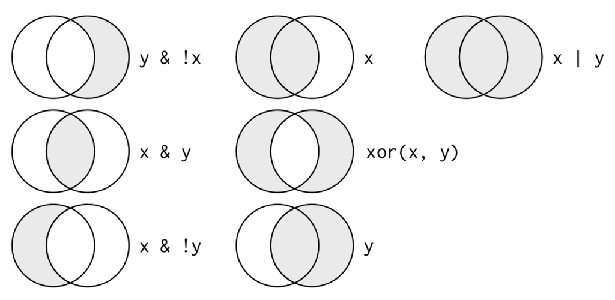

```r
knitr::include_graphics("imagenes/transform-logical.png")
```

**Ejercicio:**

1. Encuentra todos los vuelos hacia SFO ó OAK.
2. Encuentra los vuelos con un retraso mayor a una hora.
3. Encuentra los vuelos en los que el retraso de llegada es más del doble que el retraso de salida.

#### Seleccionar

Elegir columnas de un conjunto de datos.

**Ejercicio:** Ve la ayuda de select (`?select`) y escribe tres maneras de seleccionar las variables de retraso (delay).

#### Arreglar

Arreglar u ordenar de acuerdo al valor de una o más variables:

**Ejercicio:**

1. Ordena los vuelos por fecha de salida y hora.
2. ¿Cuáles son los vuelos con mayor retraso?
3. ¿Qué vuelos “ganaron”" más tiempo en el aire?

#### Mutar

Mutar consiste en crear nuevas variables aplicando una función a columnas existentes:

**Ejercicio:**

1. Calcula la velocidad en millas por hora a partir de la variable tiempo y la distancia (en millas). ¿Quá vuelo fue el más rápido?
2. Crea una nueva variable que muestre cuánto tiempo se ganó o perdió durante el vuelo.

Hay muchas funciones que podemos usar para crear nuevas variables con `mutate()`, éstas deben cumplir con la propiedad de ser funciones vectorizadas, es decir, reciben un vector de valores y devuelven un vector de la misma dimensión.

#### Summarise y resúmenes por grupo

Summarise sirve para crear nuevas bases de datos con resúmenes o agregaciones de los datos originales.

**Ejercicio:**

1.Calcula el retraso promedio por fecha. 2. ¿Qué otros resúmenes puedes hacer para explorar el retraso por fecha?

Algunas funciones útiles con *summarise* son `min()`, `max()`, `n()`, `sum()`, `mean()`, `sd()`, `median()`, `quantile()`.

Por ejemplo:

```r
flights$date_only <- as.Date(flights$date)
by_date <- group_by(flights, date_only)
no_miss <- filter(by_date, !is.na(dep))
delays <- summarise(no_miss, mean_delay = mean(dep_delay), n = n())
```

#### Operador pipeline

En R, cuando uno hace varias operaciones, es difícil leer y entender el código:

```r
hourly_delay <- filter(summarise(group_by(filter(flights, !is.na(dep_delay)),
  date_only, hour), delay = mean(dep_delay), n = n()), n > 10)
```

La dificultad radica en que usualmente los parámetros se asignan después del nombre de la función usando () y las operaciones definidas por las funciones concatenadas se ejecutan “de adentro hacia afuera” en los paréntesis.

El operador “Forward Pipe” (`%>%`) cambia este orden, de manera que un parámetro que precede a la función es enviado (*piped*) a la función. Por ejemplo:

- `x %>% f(y)` se vuelve `f(x,y)`,
- `x %>% f(y) %>% g(z)` se vuelve `g(f(x, y), z)`.

De esta forma podemos reescribir el código para poder leer las operaciones que vamos aplicando de izquierda a derecha y de arriba hacia abajo.

Veamos como cambia el código anterior:

```r
hourly_delay <- flights %>%
  filter(!is.na(dep_delay)) %>%
  group_by(date_only, hour) %>%
  summarise(delay = mean(dep_delay), n = n()) %>%
  filter(n > 10)
```

Intuitivamente podemos leer `%>%` como “después”.

**Ejercicio:**

1. ¿Qué destinos tienen el promedio de retrasos más alto?
2. ¿Qué vuelos (compañía + vuelo) ocurren diariamente?
3. En promedio, ¿cómo varían a lo largo del día los retrasos de vuelos no cancelados? (*Sugerencia*: hour + minute / 60)

#### Variables por grupo

En ocasiones es conveniente crear variables por grupo, por ejemplo estandarizar dentro de cada grupo `z = (x - mean(x)) / sd(x)`.

Veamos un ejemplo:

```r
planes <- flights %>%
  filter(!is.na(arr_delay)) %>%
  group_by(plane) %>%
  filter(n() > 30)

planes %>%
  mutate(z_delay =
    (arr_delay - mean(arr_delay)) / sd(arr_delay)) %>%
  filter(z_delay > 5)
```

```
#> # A tibble: 1,403 x 16
#> # Groups:   plane [856]
#>    date                 hour minute   dep   arr dep_delay arr_delay
#>    <dttm>              <int>  <int> <int> <int>     <int>     <int>
#>  1 2011-01-28 12:00:00    15     16  1516  1916       351       326
#>  2 2011-01-27 12:00:00    18     22  1822  1945       234       210
#>  3 2011-01-27 12:00:00    21     37  2137  2254       242       219
#>  4 2011-01-27 12:00:00     0     11    11   216       168       137
#>  5 2011-01-27 12:00:00    22     37  2237   153       227       208
#>  6 2011-01-27 12:00:00    21     28  2128   136       231       216
#>  7 2011-01-26 12:00:00    11     46  1146  1633       171       193
#>  8 2011-01-26 12:00:00     9     49   949  1436       144       180
#>  9 2011-01-21 12:00:00    19     11  1911  2352        94       112
#> 10 2011-01-20 12:00:00     6     35   635   807       780       775
#> # ... with 1,393 more rows, and 9 more variables: carrier <chr>,
#> #   flight <int>, dest <chr>, plane <chr>, cancelled <int>, time <int>,
#> #   dist <int>, date_only <date>, z_delay <dbl>
```

#### Verbos de dos tablas

¿Cómo mostramos los retrasos de los vuelos en un mapa? Para responder esta pregunta necesitamos unir la base de datos de vuelos con la de aeropuertos:

```r
location <- airports %>%
  select(dest = iata, name = airport, lat, long)

flights %>%
  group_by(dest) %>%
  filter(!is.na(arr_delay)) %>%
  summarise(
    arr_delay = mean(arr_delay),
    n = n() ) %>%
    arrange(desc(arr_delay)) %>%
    left_join(location)
```

```
#> # A tibble: 116 x 6
#>    dest  arr_delay     n name                                  lat   long
#>    <chr>     <dbl> <int> <chr>                               <dbl>  <dbl>
#>  1 ANC        26.1   124 Ted Stevens Anchorage International  61.2 -150.
#>  2 CID        17.8   406 Eastern Iowa                         41.9  -91.7
#>  3 DSM        16.0   634 Des Moines International             41.5  -93.7
#>  4 SFO        14.9  2800 San Francisco International          37.6 -122.
#>  5 BPT        14.3     3 Southeast Texas Regional             30.0  -94.0
#>  6 GRR        13.7   665 Kent County International            42.9  -85.5
#>  7 DAY        13.7   444 James M Cox Dayton Intl              39.9  -84.2
#>  8 VPS        12.5   864 Eglin Air Force Base                 30.5  -86.5
#>  9 ECP        12.4   720 <NA>                                 NA     NA
#> 10 SAV        12.3   851 Savannah International               32.1  -81.2
#> # ... with 106 more rows
```

Hay varias maneras de unir dos bases de datos y debemos pensar en el obejtivo:

```r
x <- tibble(name = c("John", "Paul", "George", "Ringo", "Stuart", "Pete"),
  instrument = c("guitar", "bass", "guitar", "drums", "bass",
     "drums"))

y <- tibble(name = c("John", "Paul", "George", "Ringo", "Brian"),
  band = c("TRUE", "TRUE", "TRUE",  "TRUE", "FALSE"))
x
```

```
#> # A tibble: 6 x 2
#>   name   instrument
#>   <chr>  <chr>
#> 1 John   guitar
#> 2 Paul   bass
#> 3 George guitar
#> 4 Ringo  drums
#> 5 Stuart bass
#> 6 Pete   drums
```

```r
y
```

```
#> # A tibble: 5 x 2
#>   name   band
#>   <chr>  <chr>
#> 1 John   TRUE
#> 2 Paul   TRUE
#> 3 George TRUE
#> 4 Ringo  TRUE
#> 5 Brian  FALSE
```

```r
inner_join(x, y)
```

```
#> # A tibble: 4 x 3
#>   name   instrument band
#>   <chr>  <chr>      <chr>
#> 1 John   guitar     TRUE
#> 2 Paul   bass       TRUE
#> 3 George guitar     TRUE
#> 4 Ringo  drums      TRUE
```

```r
left_join(x, y)
```

```
#> # A tibble: 6 x 3
#>   name   instrument band
#>   <chr>  <chr>      <chr>
#> 1 John   guitar     TRUE
#> 2 Paul   bass       TRUE
#> 3 George guitar     TRUE
#> 4 Ringo  drums      TRUE
#> 5 Stuart bass       <NA>
#> 6 Pete   drums      <NA>
```

```r
semi_join(x, y)
```

```
#> # A tibble: 4 x 2
#>   name   instrument
#>   <chr>  <chr>
#> 1 John   guitar
#> 2 Paul   bass
#> 3 George guitar
#> 4 Ringo  drums
```

```r
anti_join(x, y)
```

```
#> # A tibble: 2 x 2
#>   name   instrument
#>   <chr>  <chr>
#> 1 Stuart bass
#> 2 Pete   drums
```

Resumamos lo que observamos arriba:

| Tipo | Acción |
| --- | --- |
| inner | Incluye únicamente las filas que aparecen tanto en x como en y |
| left | Incluye todas las filas en x y las filas de y que coincidan |
| semi | Incluye las filas de x que coincidan con y |
| anti | Incluye las filas de x que no coinciden con y |

Ahora combinamos datos a nivel hora con condiciones climáticas. ¿Cuál es el tipo de unión adecuado?

```r
hourly_delay <- flights %>%
  group_by(date_only, hour) %>%
  filter(!is.na(dep_delay)) %>%
  summarise(
    delay = mean(dep_delay),
    n = n() ) %>%
  filter(n > 10)

delay_weather <- hourly_delay %>% left_join(weather)
arrange(delay_weather, -delay)
```

```
#> # A tibble: 2,091,842 x 17
#> # Groups:   date_only [365]
#>    date_only   hour delay     n date        temp dew_point humidity
#>    <date>     <int> <dbl> <int> <date>     <dbl>     <dbl>    <int>
#>  1 2011-05-12    23  184.    33 2011-01-02  43        28.9       58
#>  2 2011-05-12    23  184.    33 2011-01-03  39        27         62
#>  3 2011-05-12    23  184.    33 2011-01-04  50        45         83
#>  4 2011-05-12    23  184.    33 2011-01-05  62.6      60.8       94
#>  5 2011-05-12    23  184.    33 2011-01-06  53.1      36         52
#>  6 2011-05-12    23  184.    33 2011-01-07  46.9      36         66
#>  7 2011-05-12    23  184.    33 2011-01-08  50        43         77
#>  8 2011-05-12    23  184.    33 2011-01-09  53.1      30         41
#>  9 2011-05-12    23  184.    33 2011-01-10  41        37         86
#> 10 2011-05-12    23  184.    33 2011-01-11  39.9      32         73
#> # ... with 2,091,832 more rows, and 9 more variables: pressure <dbl>,
#> #   visibility <dbl>, wind_dir <chr>, wind_dir2 <int>, wind_speed <dbl>,
#> #   gust_speed <dbl>, precip <dbl>, conditions <chr>, events <chr>
```

**Ejercicio:**

1. ¿Qué condiciones climáticas están asociadas con retrasos en las salidas de Houston?
2. Explora si los aviones más viejos están asociados a mayores retrasos, responde con una gráfica.

### Recursos adicionales

- [Tidy Data](http://vita.had.co.nz/papers/tidy-data.pdf), Hadley Wickham.
- [The Slit-Apply-Combine Strategy for Data Analysis](http://www.jstatsoft.org/v40/i01/paper), Hadley Wickham.
- [Data Wrangling Cheat Sheet](https://www.rstudio.com/wp-content/uploads/2015/02/data-wrangling-cheatsheet.pdf), RStudio.